# Risk Factor Analysis

## Outcome Variable

**Outcome Variable:** stunted

## Predictor Variables

**Intervention Variable:** predfeed3

**Adjustment Set:**

unadjusted

## Stratifying Variables

The analysis was stratified on these variable(s):

- agecat
- studyid
- country

## Data Summary

| agecat | studyid | country | predfeed3 | stunted | n_cell | n |
| --- | --- | --- | --- | --- | --- | --- |
| Birth | EE | PAKISTAN | 1 | 0 | 20 | 35 |
| Birth | EE | PAKISTAN | 1 | 1 | 15 | 35 |
| Birth | EE | PAKISTAN | 0 | 0 | 0 | 35 |
| Birth | EE | PAKISTAN | 0 | 1 | 0 | 35 |
| Birth | GMS-Nepal | NEPAL | 1 | 0 | 317 | 458 |
| Birth | GMS-Nepal | NEPAL | 1 | 1 | 63 | 458 |
| Birth | GMS-Nepal | NEPAL | 0 | 0 | 63 | 458 |
| Birth | GMS-Nepal | NEPAL | 0 | 1 | 15 | 458 |
| Birth | MAL-ED | BANGLADESH | 1 | 0 | 141 | 215 |
| Birth | MAL-ED | BANGLADESH | 1 | 1 | 35 | 215 |
| Birth | MAL-ED | BANGLADESH | 0 | 0 | 34 | 215 |
| Birth | MAL-ED | BANGLADESH | 0 | 1 | 5 | 215 |
| Birth | MAL-ED | BRAZIL | 1 | 0 | 21 | 57 |
| Birth | MAL-ED | BRAZIL | 1 | 1 | 3 | 57 |
| Birth | MAL-ED | BRAZIL | 0 | 0 | 28 | 57 |
| Birth | MAL-ED | BRAZIL | 0 | 1 | 5 | 57 |
| Birth | MAL-ED | INDIA | 1 | 0 | 21 | 41 |
| Birth | MAL-ED | INDIA | 1 | 1 | 8 | 41 |
| Birth | MAL-ED | INDIA | 0 | 0 | 12 | 41 |
| Birth | MAL-ED | INDIA | 0 | 1 | 0 | 41 |
| Birth | MAL-ED | NEPAL | 1 | 0 | 13 | 26 |
| Birth | MAL-ED | NEPAL | 1 | 1 | 1 | 26 |
| Birth | MAL-ED | NEPAL | 0 | 0 | 11 | 26 |
| Birth | MAL-ED | NEPAL | 0 | 1 | 1 | 26 |
| Birth | MAL-ED | PERU | 1 | 0 | 134 | 223 |
| Birth | MAL-ED | PERU | 1 | 1 | 16 | 223 |
| Birth | MAL-ED | PERU | 0 | 0 | 65 | 223 |
| Birth | MAL-ED | PERU | 0 | 1 | 8 | 223 |
| Birth | MAL-ED | SOUTH AFRICA | 1 | 0 | 32 | 100 |
| Birth | MAL-ED | SOUTH AFRICA | 1 | 1 | 1 | 100 |

[output cut: 78 more lines]

The following strata were considered:

- agecat: 24 months, studyid: EE, country: PAKISTAN
- agecat: 24 months, studyid: GMS-Nepal, country: NEPAL
- agecat: 24 months, studyid: MAL-ED, country: BANGLADESH
- agecat: 24 months, studyid: MAL-ED, country: BRAZIL
- agecat: 24 months, studyid: MAL-ED, country: INDIA
- agecat: 24 months, studyid: MAL-ED, country: NEPAL
- agecat: 24 months, studyid: MAL-ED, country: PERU
- agecat: 24 months, studyid: MAL-ED, country: SOUTH AFRICA
- agecat: 24 months, studyid: MAL-ED, country: TANZANIA, UNITED REPUBLIC OF
- agecat: 6 months, studyid: EE, country: PAKISTAN
- agecat: 6 months, studyid: GMS-Nepal, country: NEPAL
- agecat: 6 months, studyid: MAL-ED, country: BANGLADESH
- agecat: 6 months, studyid: MAL-ED, country: BRAZIL
- agecat: 6 months, studyid: MAL-ED, country: INDIA
- agecat: 6 months, studyid: MAL-ED, country: NEPAL
- agecat: 6 months, studyid: MAL-ED, country: PERU
- agecat: 6 months, studyid: MAL-ED, country: SOUTH AFRICA
- agecat: 6 months, studyid: MAL-ED, country: TANZANIA, UNITED REPUBLIC OF
- agecat: Birth, studyid: EE, country: PAKISTAN
- agecat: Birth, studyid: GMS-Nepal, country: NEPAL
- agecat: Birth, studyid: MAL-ED, country: BANGLADESH
- agecat: Birth, studyid: MAL-ED, country: BRAZIL
- agecat: Birth, studyid: MAL-ED, country: INDIA
- agecat: Birth, studyid: MAL-ED, country: NEPAL
- agecat: Birth, studyid: MAL-ED, country: PERU
- agecat: Birth, studyid: MAL-ED, country: SOUTH AFRICA
- agecat: Birth, studyid: MAL-ED, country: TANZANIA, UNITED REPUBLIC OF

### Dropped Strata

Some strata were dropped due to rare outcomes:

- agecat: Birth, studyid: EE, country: PAKISTAN
- agecat: Birth, studyid: MAL-ED, country: BRAZIL
- agecat: Birth, studyid: MAL-ED, country: INDIA
- agecat: Birth, studyid: MAL-ED, country: NEPAL
- agecat: Birth, studyid: MAL-ED, country: SOUTH AFRICA
- agecat: 6 months, studyid: EE, country: PAKISTAN
- agecat: 6 months, studyid: MAL-ED, country: BRAZIL
- agecat: 24 months, studyid: EE, country: PAKISTAN
- agecat: 24 months, studyid: MAL-ED, country: BRAZIL

## Methods Detail

We’re interested in the causal parameters $E[Y_a]$ for all values of $a \in \mathcal{A}$. These parameters represent the mean outcome if, possibly contrary to fact, we intervened to set all units to have $A=a$. Under the randomization and positivity assumptions, these are identified by the statistical parameters $\psi_a=E_W[E_{Y|A,W}(Y|A=a,W)]$. In addition, we’re interested in the mean of $Y$, $E[Y]$ under no intervention (the observed mean). We will estimate these parameters by using SuperLearner to fit the relevant likelihood factors – $E_{Y|A,W}(Y|A=a,W)$ and $p(A=a|W)$, and then updating our likelihood fit using a joint TMLE.

For unadjusted analyses ($W=\{\}$), initial likelihoods were estimated using Lrnr_glm to estimate the simple $E(Y|A)$ and Lrnr_mean to estimate $p(A)$. For adjusted analyses, a small library containing Lrnr_glmnet, Lrnr_xgboost, and Lrnr_mean was used.

Having estimated these parameters, we will then use the delta method to estimate relative risks and attributable risks relative to a prespecified baseline level of $A$.

# Results Detail

## Results Plots

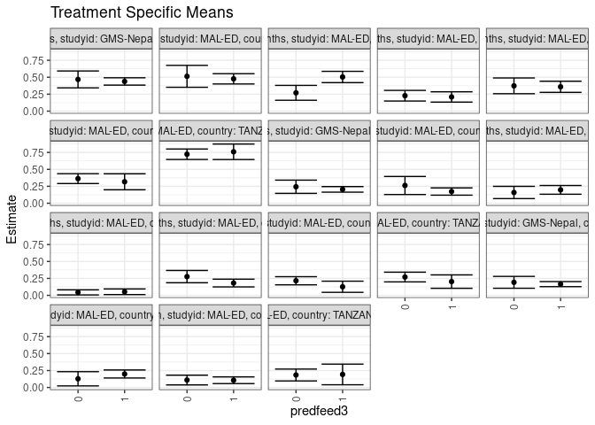

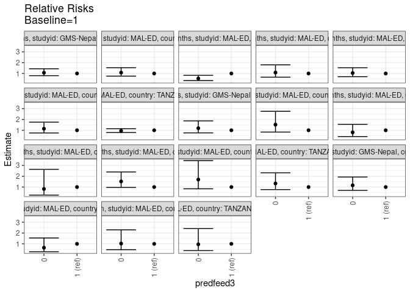

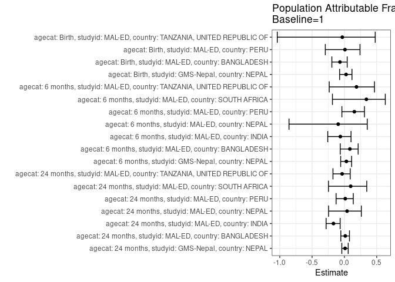

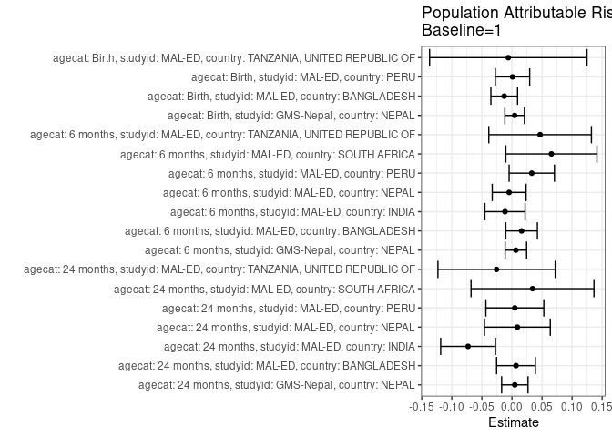

## Results Table

### Parameter: TSM

| agecat | studyid | country | intervention_level | baseline_level | estimate | ci_lower | ci_upper |
| --- | --- | --- | --- | --- | --- | --- | --- |
| Birth | GMS-Nepal | NEPAL | 1 | NA | 0.1657895 | 0.1283571 | 0.2032218 |
| Birth | GMS-Nepal | NEPAL | 0 | NA | 0.1923077 | 0.1047495 | 0.2798659 |
| Birth | MAL-ED | BANGLADESH | 1 | NA | 0.1988636 | 0.1397572 | 0.2579701 |
| Birth | MAL-ED | BANGLADESH | 0 | NA | 0.1282051 | 0.0230361 | 0.2333742 |
| Birth | MAL-ED | PERU | 1 | NA | 0.1066667 | 0.0571559 | 0.1561774 |
| Birth | MAL-ED | PERU | 0 | NA | 0.1095890 | 0.0377697 | 0.1814084 |
| Birth | MAL-ED | TANZANIA, UNITED REPUBLIC OF | 1 | NA | 0.1923077 | 0.0400700 | 0.3445454 |
| Birth | MAL-ED | TANZANIA, UNITED REPUBLIC OF | 0 | NA | 0.1842105 | 0.0966261 | 0.2717950 |
| 6 months | GMS-Nepal | NEPAL | 1 | NA | 0.2043597 | 0.1630583 | 0.2456610 |
| 6 months | GMS-Nepal | NEPAL | 0 | NA | 0.2432432 | 0.1453791 | 0.3411074 |
| 6 months | MAL-ED | BANGLADESH | 1 | NA | 0.1727749 | 0.1190448 | 0.2265050 |
| 6 months | MAL-ED | BANGLADESH | 0 | NA | 0.2619048 | 0.1286492 | 0.3951603 |
| 6 months | MAL-ED | INDIA | 1 | NA | 0.1972789 | 0.1327954 | 0.2617624 |
| 6 months | MAL-ED | INDIA | 0 | NA | 0.1587302 | 0.0682795 | 0.2491808 |
| 6 months | MAL-ED | NEPAL | 1 | NA | 0.0530973 | 0.0116634 | 0.0945313 |
| 6 months | MAL-ED | NEPAL | 0 | NA | 0.0438596 | 0.0061851 | 0.0815342 |
| 6 months | MAL-ED | PERU | 1 | NA | 0.1818182 | 0.1247307 | 0.2389057 |
| 6 months | MAL-ED | PERU | 0 | NA | 0.2765957 | 0.1860010 | 0.3671905 |
| 6 months | MAL-ED | SOUTH AFRICA | 1 | NA | 0.1269841 | 0.0445978 | 0.2093705 |
| 6 months | MAL-ED | SOUTH AFRICA | 0 | NA | 0.2154696 | 0.1554493 | 0.2754900 |
| 6 months | MAL-ED | TANZANIA, UNITED REPUBLIC OF | 1 | NA | 0.2031250 | 0.1043239 | 0.3019261 |
| 6 months | MAL-ED | TANZANIA, UNITED REPUBLIC OF | 0 | NA | 0.2702703 | 0.1985529 | 0.3419876 |
| 24 months | GMS-Nepal | NEPAL | 1 | NA | 0.4378882 | 0.3836283 | 0.4921481 |
| 24 months | GMS-Nepal | NEPAL | 0 | NA | 0.4677419 | 0.3433814 | 0.5921025 |
| 24 months | MAL-ED | BANGLADESH | 1 | NA | 0.4761905 | 0.4004841 | 0.5518968 |
| 24 months | MAL-ED | BANGLADESH | 0 | NA | 0.5135135 | 0.3520701 | 0.6749570 |
| 24 months | MAL-ED | INDIA | 1 | NA | 0.5035971 | 0.4202718 | 0.5869225 |
| 24 months | MAL-ED | INDIA | 0 | NA | 0.2698413 | 0.1599614 | 0.3797212 |
| 24 months | MAL-ED | NEPAL | 1 | NA | 0.2090909 | 0.1329230 | 0.2852588 |
| 24 months | MAL-ED | NEPAL | 0 | NA | 0.2272727 | 0.1487803 | 0.3057652 |
| 24 months | MAL-ED | PERU | 1 | NA | 0.3587786 | 0.2764351 | 0.4411221 |
| 24 months | MAL-ED | PERU | 0 | NA | 0.3731343 | 0.2570349 | 0.4892337 |
| 24 months | MAL-ED | SOUTH AFRICA | 1 | NA | 0.3166667 | 0.1987040 | 0.4346293 |
| 24 months | MAL-ED | SOUTH AFRICA | 0 | NA | 0.3630952 | 0.2902174 | 0.4359731 |
| 24 months | MAL-ED | TANZANIA, UNITED REPUBLIC OF | 1 | NA | 0.7592593 | 0.6449176 | 0.8736009 |
| 24 months | MAL-ED | TANZANIA, UNITED REPUBLIC OF | 0 | NA | 0.7230769 | 0.6459455 | 0.8002084 |

### Parameter: E(Y)

| agecat | studyid | country | intervention_level | baseline_level | estimate | ci_lower | ci_upper |
| --- | --- | --- | --- | --- | --- | --- | --- |
| Birth | GMS-Nepal | NEPAL | NA | NA | 0.1703057 | 0.1358418 | 0.2047695 |
| Birth | MAL-ED | BANGLADESH | NA | NA | 0.1860465 | 0.1339088 | 0.2381842 |
| Birth | MAL-ED | PERU | NA | NA | 0.1076233 | 0.0668572 | 0.1483894 |
| Birth | MAL-ED | TANZANIA, UNITED REPUBLIC OF | NA | NA | 0.1862745 | 0.1103463 | 0.2622027 |
| 6 months | GMS-Nepal | NEPAL | NA | NA | 0.2108844 | 0.1727677 | 0.2490010 |
| 6 months | MAL-ED | BANGLADESH | NA | NA | 0.1888412 | 0.1384789 | 0.2392035 |
| 6 months | MAL-ED | INDIA | NA | NA | 0.1857143 | 0.1329930 | 0.2384356 |
| 6 months | MAL-ED | NEPAL | NA | NA | 0.0484581 | 0.0204625 | 0.0764538 |
| 6 months | MAL-ED | PERU | NA | NA | 0.2148148 | 0.1657364 | 0.2638932 |
| 6 months | MAL-ED | SOUTH AFRICA | NA | NA | 0.1926230 | 0.1430395 | 0.2422064 |
| 6 months | MAL-ED | TANZANIA, UNITED REPUBLIC OF | NA | NA | 0.2500000 | 0.1915738 | 0.3084262 |
| 24 months | GMS-Nepal | NEPAL | NA | NA | 0.4427083 | 0.3929634 | 0.4924533 |
| 24 months | MAL-ED | BANGLADESH | NA | NA | 0.4829268 | 0.4143544 | 0.5514993 |
| 24 months | MAL-ED | INDIA | NA | NA | 0.4306931 | 0.3622377 | 0.4991484 |
| 24 months | MAL-ED | NEPAL | NA | NA | 0.2181818 | 0.1634817 | 0.2728819 |
| 24 months | MAL-ED | PERU | NA | NA | 0.3636364 | 0.2964623 | 0.4308104 |
| 24 months | MAL-ED | SOUTH AFRICA | NA | NA | 0.3508772 | 0.2887937 | 0.4129607 |
| 24 months | MAL-ED | TANZANIA, UNITED REPUBLIC OF | NA | NA | 0.7336957 | 0.6696530 | 0.7977384 |

### Parameter: RR

| agecat | studyid | country | intervention_level | baseline_level | estimate | ci_lower | ci_upper |
| --- | --- | --- | --- | --- | --- | --- | --- |
| Birth | GMS-Nepal | NEPAL | 1 | 1 | 1.0000000 | 1.0000000 | 1.0000000 |
| Birth | GMS-Nepal | NEPAL | 0 | 1 | 1.1599512 | 0.6977930 | 1.9282033 |
| Birth | MAL-ED | BANGLADESH | 1 | 1 | 1.0000000 | 1.0000000 | 1.0000000 |
| Birth | MAL-ED | BANGLADESH | 0 | 1 | 0.6446886 | 0.2694179 | 1.5426722 |
| Birth | MAL-ED | PERU | 1 | 1 | 1.0000000 | 1.0000000 | 1.0000000 |
| Birth | MAL-ED | PERU | 0 | 1 | 1.0273973 | 0.4602209 | 2.2935618 |
| Birth | MAL-ED | TANZANIA, UNITED REPUBLIC OF | 1 | 1 | 1.0000000 | 1.0000000 | 1.0000000 |
| Birth | MAL-ED | TANZANIA, UNITED REPUBLIC OF | 0 | 1 | 0.9578947 | 0.3804270 | 2.4119274 |
| 6 months | GMS-Nepal | NEPAL | 1 | 1 | 1.0000000 | 1.0000000 | 1.0000000 |
| 6 months | GMS-Nepal | NEPAL | 0 | 1 | 1.1902703 | 0.7587688 | 1.8671606 |
| 6 months | MAL-ED | BANGLADESH | 1 | 1 | 1.0000000 | 1.0000000 | 1.0000000 |
| 6 months | MAL-ED | BANGLADESH | 0 | 1 | 1.5158730 | 0.8350069 | 2.7519186 |
| 6 months | MAL-ED | INDIA | 1 | 1 | 1.0000000 | 1.0000000 | 1.0000000 |
| 6 months | MAL-ED | INDIA | 0 | 1 | 0.8045977 | 0.4171360 | 1.5519577 |
| 6 months | MAL-ED | NEPAL | 1 | 1 | 1.0000000 | 1.0000000 | 1.0000000 |
| 6 months | MAL-ED | NEPAL | 0 | 1 | 0.8260234 | 0.2588158 | 2.6362948 |
| 6 months | MAL-ED | PERU | 1 | 1 | 1.0000000 | 1.0000000 | 1.0000000 |
| 6 months | MAL-ED | PERU | 0 | 1 | 1.5212766 | 0.9664054 | 2.3947326 |
| 6 months | MAL-ED | SOUTH AFRICA | 1 | 1 | 1.0000000 | 1.0000000 | 1.0000000 |
| 6 months | MAL-ED | SOUTH AFRICA | 0 | 1 | 1.6968232 | 0.8375239 | 3.4377634 |
| 6 months | MAL-ED | TANZANIA, UNITED REPUBLIC OF | 1 | 1 | 1.0000000 | 1.0000000 | 1.0000000 |
| 6 months | MAL-ED | TANZANIA, UNITED REPUBLIC OF | 0 | 1 | 1.3305613 | 0.7645427 | 2.3156242 |
| 24 months | GMS-Nepal | NEPAL | 1 | 1 | 1.0000000 | 1.0000000 | 1.0000000 |
| 24 months | GMS-Nepal | NEPAL | 0 | 1 | 1.0681766 | 0.7966190 | 1.4323048 |
| 24 months | MAL-ED | BANGLADESH | 1 | 1 | 1.0000000 | 1.0000000 | 1.0000000 |
| 24 months | MAL-ED | BANGLADESH | 0 | 1 | 1.0783784 | 0.7581731 | 1.5338185 |
| 24 months | MAL-ED | INDIA | 1 | 1 | 1.0000000 | 1.0000000 | 1.0000000 |
| 24 months | MAL-ED | INDIA | 0 | 1 | 0.5358277 | 0.3452532 | 0.8315963 |
| 24 months | MAL-ED | NEPAL | 1 | 1 | 1.0000000 | 1.0000000 | 1.0000000 |
| 24 months | MAL-ED | NEPAL | 0 | 1 | 1.0869565 | 0.6579716 | 1.7956313 |
| 24 months | MAL-ED | PERU | 1 | 1 | 1.0000000 | 1.0000000 | 1.0000000 |
| 24 months | MAL-ED | PERU | 0 | 1 | 1.0400127 | 0.7065207 | 1.5309197 |
| 24 months | MAL-ED | SOUTH AFRICA | 1 | 1 | 1.0000000 | 1.0000000 | 1.0000000 |
| 24 months | MAL-ED | SOUTH AFRICA | 0 | 1 | 1.1466165 | 0.7510149 | 1.7506038 |
| 24 months | MAL-ED | TANZANIA, UNITED REPUBLIC OF | 1 | 1 | 1.0000000 | 1.0000000 | 1.0000000 |
| 24 months | MAL-ED | TANZANIA, UNITED REPUBLIC OF | 0 | 1 | 0.9523452 | 0.7918560 | 1.1453616 |

### Parameter: PAR

| agecat | studyid | country | intervention_level | baseline_level | estimate | ci_lower | ci_upper |
| --- | --- | --- | --- | --- | --- | --- | --- |
| Birth | GMS-Nepal | NEPAL | 1 | NA | 0.0045162 | -0.0117267 | 0.0207591 |
| Birth | MAL-ED | BANGLADESH | 1 | NA | -0.0128171 | -0.0350027 | 0.0093685 |
| Birth | MAL-ED | PERU | 1 | NA | 0.0009567 | -0.0275995 | 0.0295128 |
| Birth | MAL-ED | TANZANIA, UNITED REPUBLIC OF | 1 | NA | -0.0060332 | -0.1368996 | 0.1248333 |
| 6 months | GMS-Nepal | NEPAL | 1 | NA | 0.0065247 | -0.0113511 | 0.0244005 |
| 6 months | MAL-ED | BANGLADESH | 1 | NA | 0.0160663 | -0.0102056 | 0.0423383 |
| 6 months | MAL-ED | INDIA | 1 | NA | -0.0115646 | -0.0449755 | 0.0218462 |
| 6 months | MAL-ED | NEPAL | 1 | NA | -0.0046392 | -0.0327696 | 0.0234912 |
| 6 months | MAL-ED | PERU | 1 | NA | 0.0329966 | -0.0046719 | 0.0706652 |
| 6 months | MAL-ED | SOUTH AFRICA | 1 | NA | 0.0656388 | -0.0101306 | 0.1414083 |
| 6 months | MAL-ED | TANZANIA, UNITED REPUBLIC OF | 1 | NA | 0.0468750 | -0.0384564 | 0.1322064 |
| 24 months | GMS-Nepal | NEPAL | 1 | NA | 0.0048201 | -0.0171145 | 0.0267548 |
| 24 months | MAL-ED | BANGLADESH | 1 | NA | 0.0067364 | -0.0255071 | 0.0389799 |
| 24 months | MAL-ED | INDIA | 1 | NA | -0.0729041 | -0.1184438 | -0.0273643 |
| 24 months | MAL-ED | NEPAL | 1 | NA | 0.0090909 | -0.0456092 | 0.0637910 |
| 24 months | MAL-ED | PERU | 1 | NA | 0.0048577 | -0.0433158 | 0.0530313 |
| 24 months | MAL-ED | SOUTH AFRICA | 1 | NA | 0.0342105 | -0.0679940 | 0.1364150 |
| 24 months | MAL-ED | TANZANIA, UNITED REPUBLIC OF | 1 | NA | -0.0255636 | -0.1230398 | 0.0719126 |

### Parameter: PAF

| agecat | studyid | country | intervention_level | baseline_level | estimate | ci_lower | ci_upper |
| --- | --- | --- | --- | --- | --- | --- | --- |
| Birth | GMS-Nepal | NEPAL | 1 | NA | 0.0265182 | -0.0735854 | 0.1172879 |
| Birth | MAL-ED | BANGLADESH | 1 | NA | -0.0688920 | -0.1941495 | 0.0432269 |
| Birth | MAL-ED | PERU | 1 | NA | 0.0088889 | -0.2953346 | 0.2416622 |
| Birth | MAL-ED | TANZANIA, UNITED REPUBLIC OF | 1 | NA | -0.0323887 | -1.0387102 | 0.4772056 |
| 6 months | GMS-Nepal | NEPAL | 1 | NA | 0.0309396 | -0.0575470 | 0.1120224 |
| 6 months | MAL-ED | BANGLADESH | 1 | NA | 0.0850785 | -0.0639375 | 0.2132233 |
| 6 months | MAL-ED | INDIA | 1 | NA | -0.0622711 | -0.2577767 | 0.1028457 |
| 6 months | MAL-ED | NEPAL | 1 | NA | -0.0957361 | -0.8572107 | 0.3535264 |
| 6 months | MAL-ED | PERU | 1 | NA | 0.1536050 | -0.0389061 | 0.3104435 |
| 6 months | MAL-ED | SOUTH AFRICA | 1 | NA | 0.3407633 | -0.1850142 | 0.6332592 |
| 6 months | MAL-ED | TANZANIA, UNITED REPUBLIC OF | 1 | NA | 0.1875000 | -0.2347442 | 0.4653498 |
| 24 months | GMS-Nepal | NEPAL | 1 | NA | 0.0108878 | -0.0399297 | 0.0592221 |
| 24 months | MAL-ED | BANGLADESH | 1 | NA | 0.0139490 | -0.0551566 | 0.0785287 |
| 24 months | MAL-ED | INDIA | 1 | NA | -0.1692715 | -0.2827858 | -0.0658021 |
| 24 months | MAL-ED | NEPAL | 1 | NA | 0.0416667 | -0.2447615 | 0.2621858 |
| 24 months | MAL-ED | PERU | 1 | NA | 0.0133588 | -0.1284275 | 0.1373297 |
| 24 months | MAL-ED | SOUTH AFRICA | 1 | NA | 0.0975000 | -0.2462646 | 0.3464419 |
| 24 months | MAL-ED | TANZANIA, UNITED REPUBLIC OF | 1 | NA | -0.0348422 | -0.1767899 | 0.0899833 |